# Final Project Recommender System Assessment

## Model Selection

The proposed recommendation system operates akin to a preference-based matching network, involving a collection of cards and users. In practice, for each user, a card ranking would be established based on the predicted click probability generated by our most accurate predictive model. The resulting card rankings determine the positions of card recommendations on the Discovery Subtab within the application.

While we have observed the classic classification performance metrics and can select a "best model" based on that, we further explore the efficacy of the proposed recommender system in comparison to the existing baseline recommender system, utilizing the "Precision and Recall at K" methodology. This approach gauges the success ratio of the existing and proposed recommender system within the top K impressions. The following article was referenced for guidance in this notebook: [Recall and Precision at k for Recommender Systems](https://medium.com/@m_n_malaeb/recall-and-precision-at-k-for-recommender-systems-618483226c54).

**Load Libraries**

```python
import warnings
warnings.filterwarnings('ignore')

import pandas as pd
import numpy as np
import matplotlib.pyplot as plt
import plotly.express as px
import seaborn as sns
import pyarrow.parquet as pq
import pyarrow as pa

from sklearn.ensemble import RandomForestClassifier
from sklearn.tree import DecisionTreeClassifier


from joblib import load
```

**Import Data**

```python
#Train set
X_train = pd.read_parquet('./data_treated/X_train.parquet')
X_train_no_probs = X_train.drop(['impressPosition', 'prior_user_probClick', 'prior_card_probClick'], axis=1)
y_train = pd.read_parquet('./data_treated/y_train.parquet')

#Full set
X_encoded =  pd.read_parquet('./data_treated/X_encoded_v2.parquet')
y = pd.read_parquet('./data_treated/y.parquet')
```

### Predict Click-Through Probability using ML Models

**Regularized Logisitic Regression**

```python
model_path = './models/logistic_regression_model.joblib'
best_lr_model = load(model_path)
best_lr_model = best_lr_model.fit(X_train_no_probs, y_train)
```

**Random Forest**

```python
best_rf_params = {'max_depth': 5, 'n_estimators': 50}
best_rf_model = RandomForestClassifier(random_state=0, max_depth = best_rf_params['max_depth'],
                                    n_estimators=best_rf_params['n_estimators'],class_weight='balanced')
best_rf_model = best_rf_model.fit(X_train_no_probs, y_train)
```

**Decision Tree**

```python
best_dt_params = {'min_samples_split': 200, 'max_depth': 5, 'criterion': 'entropy'}
best_dt_model = DecisionTreeClassifier(random_state=0, max_depth = best_dt_params['max_depth'],
                                       criterion=best_dt_params['criterion'],
                                       min_samples_split = best_dt_params['min_samples_split'],
                                       class_weight='balanced')



best_dt_model = best_dt_model.fit(X_train_no_probs, y_train)
```

**Predictions Datatset**

```python
predictions = pd.DataFrame({'userId': X_encoded['userId'],
                            'mlogId': X_encoded['mlogId'],
                            'dt':X_encoded['dt'],
                            'impressPosition': X_encoded['impressPosition'],
                            'ClickProb_predicted_LR': best_lr_model.predict_proba(X_encoded[X_train_no_probs.columns])[:, 1],
                            'ClickProb_predicted_DT': best_dt_model.predict_proba(X_encoded[X_train_no_probs.columns])[:, 1],
                            'ClickProb_predicted_RF': best_rf_model.predict_proba(X_encoded[X_train_no_probs.columns])[:, 1],
                            'isClick': y['isClick']})
```

```python
predictions.head()
```

|  | userId | mlogId | dt | impressPosition | ClickProb_predicted_LR | ClickProb_predicted_DT | ClickProb_predicted_RF | isClick |
| --- | --- | --- | --- | --- | --- | --- | --- | --- |
| 0 | ICNCKCICLCLCOCHCIC | MCJCGCGCNCPCGC | 3 | 17 | 0.505775 | 0.509721 | 0.628857 | 1 |
| 1 | PCKCLCMCMCJCLCLCNCMC | NCJCICICMCGCLC | 19 | 1 | 0.367200 | 0.331395 | 0.438076 | 0 |
| 2 | PCJCKCHCJCLCOCOCMCGC | KCPCOCKCICJCPC | 15 | 2 | 0.682075 | 0.484642 | 0.604640 | 0 |
| 3 | KCJCNCHCHCLCICGCLC | NCNCNCJCKCLCHC | 8 | 3 | 0.419601 | 0.509721 | 0.495037 | 0 |
| 4 | PCLCKCJCPCPCJCGCNCHC | LCOCHCOCMCLC | 2 | 58 | 0.544251 | 0.429897 | 0.441872 | 0 |

### Precision in K Assessment

```python
def precision_recall_at_k(predictions_df, relevant_col, recommended_col):
    recommended = np.sum(predictions_df[recommended_col])
    relevant = np.sum(predictions_df[relevant_col])
    recommended_relevant = np.sum((predictions_df[relevant_col] ==1) & predictions_df[recommended_col] ==1 )
    precision_at_k = recommended_relevant / recommended
    recall_at_k = recommended_relevant / relevant

    return precision_at_k, recall_at_k
```

```python
K=6
ClickProb_threshold =  0.5
```

```python
#Logistic Regression
predictions = predictions.sort_values(['userId', 'dt', 'ClickProb_predicted_LR'], ascending=False)

predictions['LR_recommended_at_k'] =  (predictions[predictions['ClickProb_predicted_LR'] >= ClickProb_threshold]
                                   .groupby(['userId', 'dt'])
                                   .cumcount()
                                   .add(1)
                                   .where(lambda x: x <= K, 0))



#Random Forest
predictions = predictions.sort_values(['userId', 'dt', 'ClickProb_predicted_RF'], ascending=False)

predictions['RF_recommended_at_k'] =  (predictions[predictions['ClickProb_predicted_RF'] >= ClickProb_threshold]
                                   .groupby(['userId', 'dt'])
                                   .cumcount()
                                   .add(1)
                                   .where(lambda x: x <= K, 0))


#Decision Tree
predictions = predictions.sort_values(['userId', 'dt', 'ClickProb_predicted_DT'], ascending=False)

predictions['DT_recommended_at_k'] =  (predictions[predictions['ClickProb_predicted_DT'] >= ClickProb_threshold]
                                   .groupby(['userId', 'dt'])
                                   .cumcount()
                                   .add(1)
                                   .where(lambda x: x <= K, 0))

#Existing
predictions['current_recommended_at_k'] = np.where(predictions['impressPosition'] <= K, 1, 0)
```

```python
predictions = predictions.fillna(0)
```

```python
precision_at_k = {}
recall_at_k = {}
```

**Current Recommender System**

```python
precision_at_k_current, recall_at_k_current = precision_recall_at_k(predictions, 'isClick', 'current_recommended_at_k')

print(f"Precision at {K} =  {precision_at_k_current}")
print(f"Recall at {K} =  {recall_at_k_current}")
```

```
Precision at 6 =  0.03262713625073803
Recall at 6 =  0.4065608117328795
```

**Logistic Regression Recommender System**

```python
precision_at_k_LR, recall_at_k_LR = precision_recall_at_k(predictions, 'isClick', 'LR_recommended_at_k')

precision_at_k['Logistic Regression'] = precision_at_k_LR
recall_at_k['Logistic Regression'] = recall_at_k_LR

print(f"Precision at {K} =  {precision_at_k_LR}")
print(f"Recall at {K} =  {recall_at_k_LR}")
```

```
Precision at 6 =  0.036338814826918864
Recall at 6 =  0.40523628715692805
```

**Decision Tree Recommender System**

```python
precision_at_k_DT, recall_at_k_DT = precision_recall_at_k(predictions, 'isClick', 'DT_recommended_at_k')

precision_at_k['Decision Tree'] = precision_at_k_DT
recall_at_k['Decision Tree'] = recall_at_k_DT

print(f"Precision at {K} =  {precision_at_k_DT}")
print(f"Recall at {K} =  {recall_at_k_DT}")
```

```
Precision at 6 =  0.03582251478766674
Recall at 6 =  0.5454873849068418
```

**Random Forest Recommender System**

```python
precision_at_k_RF, recall_at_k_RF = precision_recall_at_k(predictions, 'isClick', 'RF_recommended_at_k')

precision_at_k['Random Forest'] = precision_at_k_RF
recall_at_k['Random Forest'] = recall_at_k_RF

print(f"Precision at {K} =  {precision_at_k_RF}")
print(f"Recall at {K} =  {recall_at_k_RF}")
```

```
Precision at 6 =  0.04070971853301191
Recall at 6 =  0.33537765005257963
```

**Compare Metrics**

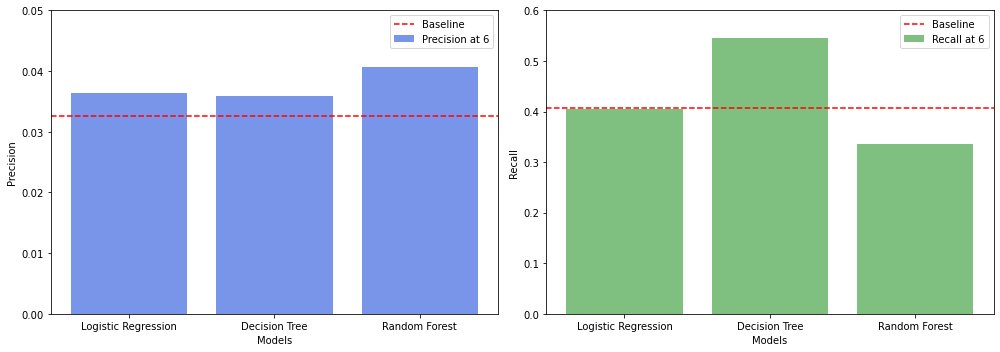

```python
models = list(precision_at_k.keys())

fig, (ax1, ax2) = plt.subplots(1, 2, figsize=(14, 5))

ax1.bar(models, precision_at_k.values(), color='royalblue', alpha=0.7, label=f'Precision at {K}')
ax1.axhline(y=precision_at_k_current, color='red', linestyle='--', label='Baseline')
ax1.set_ylim(0, 0.05)
ax1.set_xlabel('Models')
ax1.set_ylabel('Precision')
ax1.legend()

ax2.bar(models, recall_at_k.values(), color='green', alpha=0.5, label=f'Recall at {K}')
ax2.axhline(y=recall_at_k_current, color='red', linestyle='--', label='Baseline')
ax2.set_ylim(0, 0.6)
ax2.set_xlabel('Models')
ax2.set_ylabel('Recall')
ax2.legend()

plt.tight_layout()
plt.show()
```